## PeerAssessment 1

### Loading and preprocessing the data

```r
setwd("C:/DataSciencecoursera/Reproducible Research")
data_set<-read.csv("activity.csv",header=TRUE,sep=",")
```

### What is mean total number of steps taken per day?

```r
#calculate the total steps taken each day by applying sum function, group by date
totalSteps_eachDay<-aggregate (data_set$steps,list(date=data_set$date),FUN=sum,na.rm=FALSE)
```

Histogram of the total number of steps taken each day

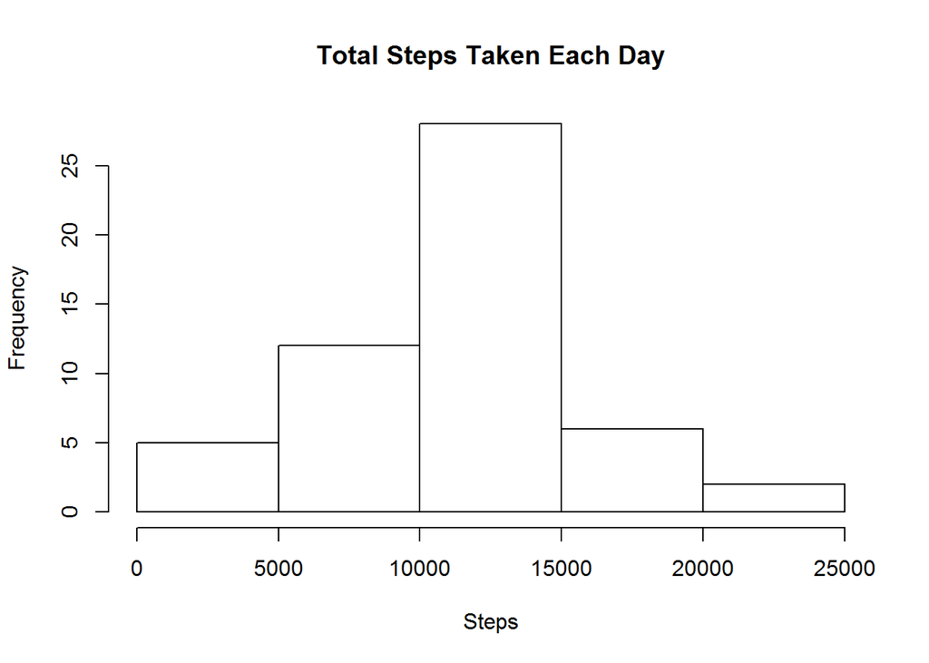

```r
hist(totalSteps_eachDay[,2],main="Total Steps Taken Each Day",xlab = "Steps",ylab="Frequency")
```

Mean total number of steps taken per day

```r
#calculate the mean steps taken per day
mean(as.numeric(totalSteps_eachDay[,2]),na.rm=TRUE)
```

```
## [1] 10766.19
```

Median total number of steps taken per day

```r
#calculate the median of  steps taken per day
median(as.numeric(totalSteps_eachDay[,2]),na.rm=TRUE)
```

```
## [1] 10765
```

### What is the average daily activity pattern?

Time series plot of the 5-minute interval and the average number of steps taken, averaged across all days

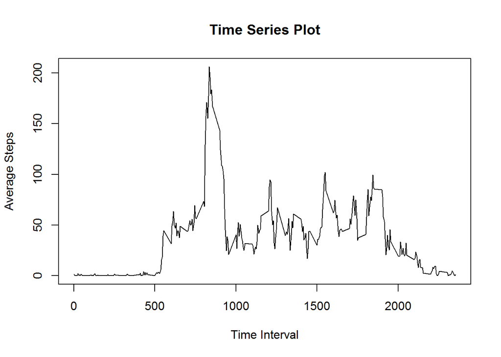

```r
#Calculate the average (mean) steps for each day by applying mean function, group by interval
meanOf_StepsInInterval<-aggregate (data_set$steps,list(interval=data_set$interval),FUN=mean,na.rm=TRUE)

plot(meanOf_StepsInInterval,xlab="Time Interval",ylab="Average Steps",main="Time Series Plot",type='l')
```

5-minute interval, on average across all the days that contains the maximum number of steps

```r
#get the row number that has max steps
rowID_WithMaxValue<-which.max(meanOf_StepsInInterval$x)
#get the interval with max steps using the row id
meanOf_StepsInInterval[rowID_WithMaxValue,1]
```

```
## [1] 835
```